This script does some quick comparisons of the scans following QC

# Two Scans

Here we examine subjects who have 645 and 1400ms TR scans that pass QC. We look at the distribution of ages and the breakdown of sex and handedness.

```r
sdf <- subset(df, short == 1 & medium == 1)
```

Age appears to be bimodally distributed, is this an issue?

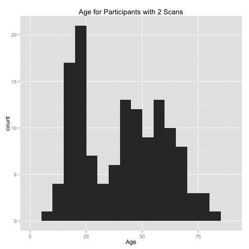

```r
ggplot(sdf, aes(Age)) + geom_histogram(binwidth = 5) + ggtitle("Age for Participants with 2 Scans")
```

Note there is one participant who doesn't have gender recorded.

```r
table(sdf$Sex)
```

```
##
##     F  M
##  1 86 45
```

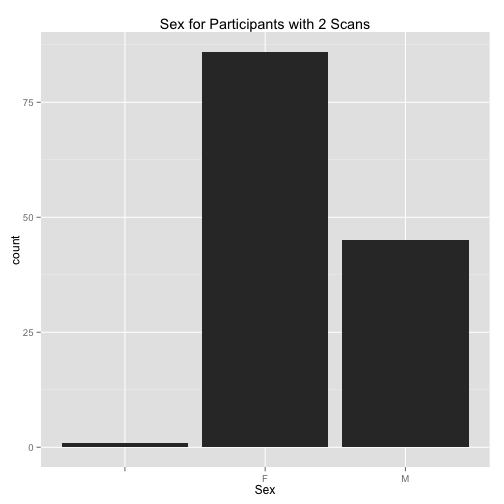

```r
ggplot(sdf, aes(Sex)) + geom_bar() + ggtitle("Sex for Participants with 2 Scans")
```

Woot, majority of people are right-handed.

```r
table(sdf$Handedness)
```

```
##
##  Left  None Right
##     7    10   115
```

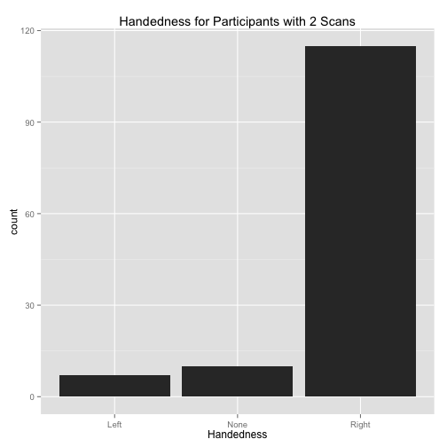

```r
ggplot(sdf, aes(Handedness)) + geom_bar() + ggtitle("Handedness for Participants with 2 Scans")
```

```r
### Examine all three scans
```

# Three Scans

Here I will be seeing how the distribution of the subjects from above will differ with the removal of subjects who don't have a 3rd scan. Where color is shown, red means subjects with only two scans, while blue means subjects with all three scans usable. Subjects that would be lost if looking at three scans are in red (shown first) Only subjects with three usable scans are shown second.

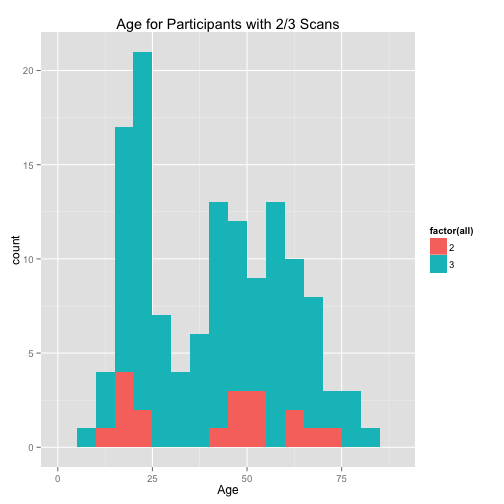

```r
ggplot(sdf, aes(Age, fill = factor(all))) + geom_histogram(binwidth = 5) + ggtitle("Age for Participants with 2/3 Scans")
```

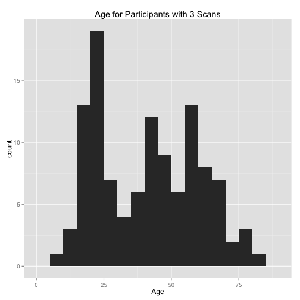

```r
ggplot(sdf[sdf$all == 3, ], aes(Age)) + geom_histogram(binwidth = 5) + ggtitle("Age for Participants with 3 Scans")
```

The first table output is for 2 scans and the second is for 3 scans.

```r
table(sdf$Sex)
```

```
##
##     F  M
##  1 86 45
```

```r
table(sdf$Sex[sdf$all == 3])
```

```
##
##     F  M
##  1 77 36
```

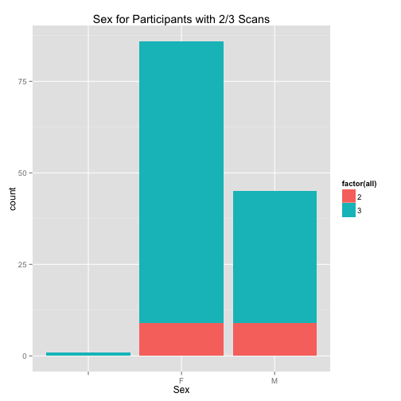

```r
ggplot(sdf, aes(Sex, fill = factor(all))) + geom_bar() + ggtitle("Sex for Participants with 2/3 Scans")
```

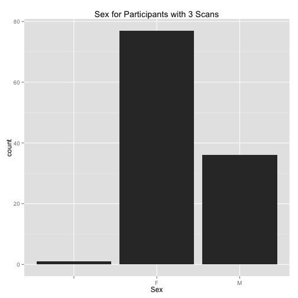

```r
ggplot(sdf[sdf$all == 3, ], aes(Sex)) + geom_bar() + ggtitle("Sex for Participants with 3 Scans")
```

The first table output is for 2 scans and the second is for 3 scans. Woot, majority of people are still right-handed.

```r
table(sdf$Handedness)
```

```
##
##  Left  None Right
##     7    10   115
```

```r
table(sdf$Handedness[sdf$all == 3])
```

```
##
##  Left  None Right
##     6     9    99
```

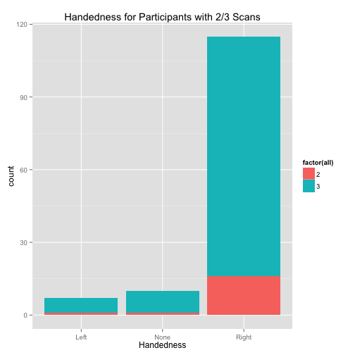

```r
ggplot(sdf, aes(Handedness, fill = factor(all))) + geom_bar() + ggtitle("Handedness for Participants with 2/3 Scans")
```

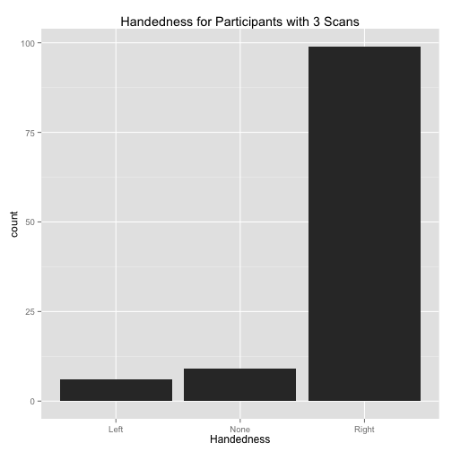

```r
ggplot(sdf[sdf$all == 3, ], aes(Handedness)) + geom_bar() + ggtitle("Handedness for Participants with 3 Scans")
```